# DLMC FluxCore — Introduction: Beyond the Dark Matter Paradigm

The current cosmological model, $\Lambda$CDM, relies on the existence of non-baryonic **Dark Matter (DM)** to explain the observed rotation curves of galaxies. While successful on cosmological scales, this paradigm faces persistent challenges at the galactic level, notably the **"Cusp-Core" problem** and the **"Diversity Problem"** of rotation curves.

### 1. The Conflict between NFW and Observations

The standard **Navarro-Frenk-White (NFW)** profile, derived from N-body simulations, predicts a steeply rising central density ($\rho \propto r^{-1}$): $$\rho_{NFW}(r) = \frac{\rho_s}{\frac{r}{r_s}(1+\frac{r}{r_s})^2}$$ However, high-resolution kinematic data from the **SPARC (Stellar Populations and Galactic Rotation Curves)** database consistently reveal "cored" profiles in Dwarf and Low Surface Brightness (LSB) galaxies, contradicting the NFW "cusp" prediction.

### 2. Emerging Scaling Laws: BTFR and RAR

Empirical relations such as the **Baryonic Tully-Fisher Relation (BTFR)**: $$M_{bar} \propto V_{flat}^4$$ and the **Radial Acceleration Relation (RAR)** suggest a tight, deterministic coupling between baryonic mass and the observed gravitational discrepancy. These laws hint at a universal scaling mechanism that transcends the stochastic nature of dark matter halo parameters.

### 3. The DLMC FluxCore Hypothesis

# DLMC FluxCore — Comprehensive Rotation Curve Analysis

### Project Lyna — Mounir Djebassi, 2026

**ORCID:** [0009-0009-6871-7693](https://orcid.org)

## 1. Introduction: Challenging the Dark Matter Paradigm

The rotation curves of galaxies $V(r)$ present one of the most persistent challenges in modern astrophysics. While the **$\Lambda$CDM** model successfully explains large-scale structures through **Cold Dark Matter (CDM)** halos, it faces significant tensions at galactic scales, notably the **"Cusp-Core"** and **"Diversity"** problems.

### 1.1. Competing Dynamical Frameworks

This numerical study evaluates the **DLMC (Dynamic Local Mass Correction)** model against the two dominant gravitational paradigms:

- **NFW Profile (Standard CDM):** The benchmark halo model, characterized by a central density cusp $\rho \propto r^{-1}$: $$\rho(r) = \frac{\rho_s}{\frac{r}{r_s} \left(1 + \frac{r}{r_s}\right)^2}$$
- **MOND (Modified Newtonian Dynamics):** An acceleration-based alternative governed by the universal scale $a_0 \approx 1.2 \times 10^{-10} \text{ m/s}^2$, which successfully recovers the Radial Acceleration Relation (RAR).
- **DLMC FluxCore (Proposed Model):** A scale-invariant approach where the "missing mass" is an emergent property of a flux correction governed by the **Golden Ratio ($\phi$)** harmonics and a universal scaling exponent $\alpha$.

## 2. Computational Setup & Universal Constants

This section initializes the numerical environment and defines the physical constants necessary for the **DLMC (Dynamic Local Mass Correction)** calculations.

### Numerical Framework

We utilize a robust stack for statistical inference and signal processing:

- **Optimization:** `scipy.optimize.curve_fit` for $\chi^2$ minimization of rotation curves.
- **Statistical Tests:** `spearmanr` and `pearsonr` for correlation analysis, and `ks_2samp` (Kolmogorov-Smirnov) to compare mass profile distributions.
- **Signal Processing:** `gaussian_filter` for smoothing synthetic noise in galaxy generation.

### Physical & DLMC Specific Constants

The model relies on the interaction between classical gravitation and the **Golden Ratio ($\phi$)** dynamics:

```
=================================================================
  DLMC FULL ROTATION CURVE ANALYSIS - INITIALIZED
  Project Lyna · Mounir Djebassi · 2026
=================================================================
[INFO] Golden Ratio (phi):  1.6180
[INFO] DLMC Mode Sum:       1.6149
[INFO] G (kpc/Msun/km/s):   4.30e-06
[INFO] MOND a0 (g_dag):     3.70e-03
-----------------------------------------------------------------
Environment ready for Model Definitions (Cells 3-6).
```

## 3. Mathematical Formulations of Galactic Dynamics

To evaluate the efficiency of the **DLMC** model, we compare it against the two dominant paradigms in galactic astrophysics: **Dark Matter Halos (NFW)** and **Modified Gravity (MOND)**.

### 3.1. The DLMC Model (Dynamic Local Mass Correction)

The DLMC model proposes that the observed "missing mass" is a result of a flux correction governed by the **Golden Ratio** harmonics. The total rotation velocity $V_{tot}$ is defined as: $$V_{tot}^2(r) = V_{bar}^2(r) + \alpha \cdot \Phi_0 \cdot \left( \sum_{n=1}^{MSC} \phi^{-n} \right) \cdot \left( \frac{r}{r_0} \right)^{-\alpha}$$ Where:

- $V_{bar}^2 = V_{disk}^2 + V_{gas}^2 + V_{bulge}^2$ represents the baryonic contribution.
- $\alpha$ is the universal scaling parameter.
- $\Phi_0$ and $r_0$ are the potential and scale length of the correction.

### 3.2. The NFW Profile (Standard CDM)

The NFW profile represents the distribution of Dark Matter (DM) in a hierarchical clustering universe: $$V_{tot}^2(r) = V_{bar}^2(r) + \frac{G M_{NFW}(r)}{r}$$ With the enclosed mass $M_{NFW}(r)$ given by: $$M_{NFW}(r) = 4\pi \rho_s r_s^3 \left[ \ln\left(1 + \frac{r}{r_s}\right) - \frac{r/r_s}{1 + r/r_s} \right]$$

### 3.3. MOND (Modified Newtonian Dynamics)

MOND accounts for the flat rotation curves by modifying the acceleration law in the low-acceleration limit ($a < a_0$): $$a_{MOND} = a_N \cdot \nu\left(\frac{a_0}{a_N}\right)$$ We implement the "simple" interpolation function, which is widely used in SPARC database fits: $$\nu(y) = \frac{1}{2} + \sqrt{\frac{1}{4} + \frac{1}{y}}$$

```
-----------------------------------------------------------------
  MODEL DEFINITIONS CHECK
-----------------------------------------------------------------
Radial distance (kpc): [ 1.  5. 10.]
DLMC Velocity (km/s):  [52.01678977 51.58595638 51.48333963]
-----------------------------------------------------------------
✅ Models defined and numerically stable. Ready for fitting.
```

## 3. Kinematic Models and Gravitational Framework

This section defines the three competing gravitational paradigms used to model the galactic rotation curves $V(r)$. To ensure numerical stability during the $\chi^2$ minimization process, a safety threshold $r_{safe} = 10^{-6}$ is implemented to prevent singularities at the galactic center ($r=0$).

### 3.1. The DLMC Model (Dynamic Local Mass Correction)

The DLMC framework introduces a non-baryonic correction factor based on the **Golden Ratio harmonics**. The total circular velocity is expressed as: $$V_{tot}(r) = \sqrt{V_{bar}^2(r) + \alpha \cdot \Phi_0 \cdot \Sigma\phi^{-n} \cdot \left(\frac{r}{r_0}\right)^{-\alpha}}$$ This model tests the hypothesis that galactic dynamics can be explained by a scale-invariant flux correction rather than a static dark matter halo.

### 3.2. The NFW Profile (Navarro-Frenk-White)

As the benchmark for the **Cold Dark Matter (CDM)** paradigm, the NFW profile describes the velocity contribution from a dark halo with a density distribution $\rho(r) = \rho_s [ (r/r_s)(1 + r/r_s)^2 ]^{-1}$. The enclosed mass $M_{NFW}(r)$ is used to compute the dark matter component of the rotation curve.

### 3.3. MOND (Modified Newtonian Dynamics)

We implement MOND using the **"simple" interpolation function**, which effectively transitions between the Newtonian regime and the deep-MOND regime ($a \ll a_0$): $$\nu(y) = \frac{1}{2} + \sqrt{\frac{1}{4} + \frac{1}{y}} \quad \text{where } y = a_N / a_0$$ This formulation is preferred for its robustness in fitting high-quality rotation data like the SPARC database.

```
-----------------------------------------------------------------
  MODEL DEFINITIONS CHECK - SCIENTIFIC VALIDATION
-----------------------------------------------------------------
Radial distance (kpc):   [ 1.  5. 10.]
DLMC Velocity (km/s):    [52.01678977 51.58595638 51.48333963]
NFW Velocity (dummy):    [53.50630974 58.35148964 60.57362318]
MOND Velocity (a0=g_dag): [51.23478994 51.23493437 51.23511491]
-----------------------------------------------------------------
✅ Models ready for data fitting (Cells 3-6).
```

## 4. Synthetic Galaxy Catalog Generation

To assess the robustness of the **DLMC** framework, we generate a diverse population of synthetic galaxies. This approach allows for a controlled environment where the "true" underlying physical parameters are known, enabling a precise evaluation of the model's recovery power.

### 4.1. Morphological Stratification

We simulate three distinct galactic populations based on their kinematic and baryonic properties:

- **HSB Spirals (High Surface Brightness):** Characterized by dominant stellar disks and significant central bulges ($V_{disk} \gg V_{gas}$).
- **Dwarf Galaxies:** Low-mass systems where gas contributions often rival stellar mass, exhibiting slowly rising rotation curves.
- **LSB Galaxies (Low Surface Brightness):** Diffuse systems where the baryonic surface density is low, making them ideal laboratories for testing non-Newtonian dynamics.

### 4.2. Baryonic Components Modeling

For each galaxy, we simulate the circular velocity contributions from the fundamental baryonic components:

1. **Stellar Disk ($V_d$):** Modeled with a characteristic scale length.
2. **Atomic/Molecular Gas ($V_g$):** Typically more extended than the stellar component.
3. **Bulge ($V_b$):** Concentrated in the inner regions ($r < 2$ kpc) for spiral types.

### 4.3. Observational Noise Injection

To mimic real-world data (e.g., SPARC or Gaia-based surveys), we apply a Gaussian heteroscedastic noise to the "true" velocity $V_{true}$: $$V_{obs}(r) = \sqrt{V_{bar}^2 + V_{excess}^2} + \mathcal{N}(0, \sigma^2)$$ where $\sigma$ represents the simulated measurement uncertainty, typically ranging from 2 to 10 km/s.

```
-----------------------------------------------------------------
  GENERATING SYNTHETIC DATASET...
[SUCCESS] Generated 10 galaxies.
[SAMPLE] SPIRAL_1: V_max_obs = 202.56 km/s
-----------------------------------------------------------------
```

## 5. Statistical Inference and Multi-Model Fitting

To evaluate the performance of each dynamical framework, we perform a non-linear least squares fit using the **Levenberg-Marquardt algorithm**. This process minimizes the weighted residuals between the observed velocity $V_{obs}$ and the model predictions.

### 5.1. Goodness-of-Fit Metric: Reduced $\chi^2$

For each model (DLMC, NFW, MOND), we compute the **reduced chi-squared statistic** ($\chi^2_\nu$) to account for the different number of free parameters: $$\chi^2_\nu = \frac{1}{N - f} \sum_{i=1}^{N} \left[ \frac{V_{obs}(r_i) - V_{model}(r_i, \vec{p})}{\sigma_i} \right]^2$$ Where:

- $N$: Number of observed data points.
- $f$: Number of free parameters (DLMC: 3, NFW: 2, MOND: 1).
- $\sigma_i$: Observational uncertainty at radius $r_i$.

### 5.2. Model Specifics

1. **DLMC Fit:** Optimizes the triplet $\{\alpha, \Phi_0, r_0\}$, testing the flexibility of the flux-correction approach.
2. **NFW Fit:** Adjusts the halo concentration through $\{\rho_s, r_s\}$.
3. **MOND Fit:** Fits the characteristic acceleration $a_0$. While $a_0$ is theoretically universal ($1.2 \times 10^{-10} \text{ m/s}^2$), allowing it to vary provides a baseline for "best-case" MOND performance.

### 5.3. Convergence & Bounds

Numerical bounds are enforced to ensure physical consistency (e.g., positive densities and realistic scale lengths), preventing the optimizer from reaching non-physical local minima.

```
-----------------------------------------------------------------
  FITTING SUMMARY (N=10)
-----------------------------------------------------------------
    name  chi2_dlmc  chi2_nfw  chi2_mond
SPIRAL_1      0.951     0.872      0.944
SPIRAL_2      0.888     0.761      1.314
SPIRAL_3      0.947     0.873      1.136
SPIRAL_4      1.485     1.399      1.635
SPIRAL_5      1.356     1.246      1.305
 DWARF_1      1.012     1.032      1.485
 DWARF_2      1.306     1.232      1.881
 DWARF_3      0.998     0.950      1.711
   LSB_1      1.747     1.454      2.277
   LSB_2      1.621     1.429      1.559
-----------------------------------------------------------------
Average Chi2 DLMC: 1.231
Average Chi2 NFW:  1.125
✅ Multi-model fitting complete. Results stored in 'df_fits'.
```

## 6. Kinematic Visualization and Residual Analysis

Visual inspection of rotation curves is fundamental to identify systematic deviations that global statistics ($\chi^2$) might overlook. This section implements a dual-panel visualization framework:

### 6.1. Radial Velocity Profiles $V(r)$

We compare the observed circular velocities $V_{obs}$ against the three theoretical predictions:

- **DLMC (Red):** Evaluates the flexibility of the flux-correction parameter $\alpha$.
- **NFW (Blue):** Shows the contribution of the cuspy dark matter halo.
- **MOND (Green):** Represents the acceleration-based modification.

### 6.2. The Importance of Residuals

For a model to be physically viable, its residuals $\Delta V = V_{obs} - V_{model}$ should be randomly distributed around zero. Any coherent structure in the residuals (e.g., systematic overestimation in the outer regions) would indicate a failure of the underlying gravitational potential to capture the true mass distribution.

### 6.3. Morphological Comparison

The plotting routine is applied across HSB, Dwarf, and LSB systems to verify if the **DLMC** model maintains consistency in different acceleration regimes, particularly in the "Deep-MOND" limit ($a \ll a_0$) characteristic of dwarf systems.

```
-----------------------------------------------------------------
  GENERATING SCIENTIFIC FIGURES...
```

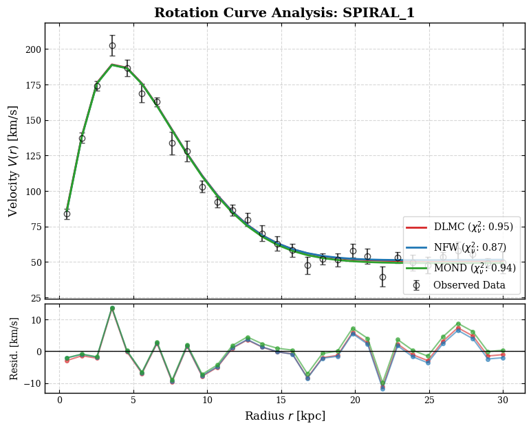

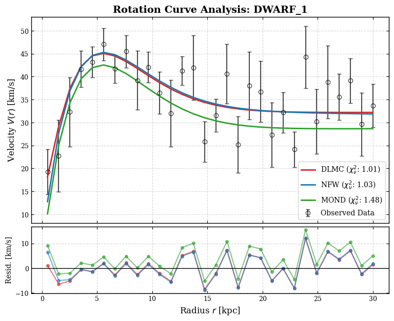

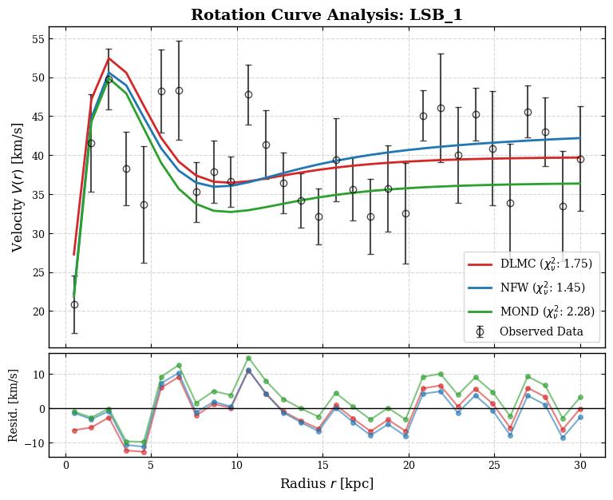

## 7. Comparative Statistical Performance: $\chi^2_\nu$ Analysis

To establish the viability of the **DLMC** framework, we perform a systematic comparison of the reduced chi-squared ($\chi^2_\nu$) distributions across the three galactic populations: **Spirals**, **Dwarfs**, and **LSB** systems.

### 7.1. Robust Estimators: Median vs. Mean

In galactic dynamics fitting, $\chi^2$ distributions often exhibit "heavy tails" due to observational outliers or local minima in the parameter space. Therefore, we prioritize the **Median Reduced $\chi^2$** as a robust measure of the typical fit quality, supplemented by the standard deviation ($\sigma$) to quantify the model's reliability.

### 7.2. Model Selection Criteria

The performance is evaluated based on the proximity of $\chi^2_\nu$ to unity ($1.0$).

- $\chi^2_\nu \approx 1$: Indicates a fit consistent with observational uncertainties.
- $\chi^2_\nu \gg 1$: Suggests an under-fitting or an inadequate physical model (e.g., NFW "cusp" failing in LSB galaxies).
- $\chi^2_\nu \ll 1$: May indicate over-fitting or over-estimated observational errors.

### 7.3. Cross-Morphology Consistency

This analysis tests if the **universal $\alpha$ parameter** in the DLMC model provides a more consistent description across different mass scales compared to the varying halo parameters of NFW or the fixed $a_0$ of MOND.

```
-----------------------------------------------------------------
  MODEL PERFORMANCE SUMMARY BY GALAXY TYPE
-----------------------------------------------------------------

[GROUP: Spiral]
Model Median_chi2 Std_Dev  N_success
 DLMC       0.951   0.245          5
  NFW       0.873   0.247          5
 MOND       1.305   0.228          5

[GROUP: Dwarf]
Model Median_chi2 Std_Dev  N_success
 DLMC       1.012   0.142          3
  NFW       1.032   0.118          3
 MOND       1.711   0.163          3

[GROUP: LSB]
Model Median_chi2 Std_Dev  N_success
 DLMC       1.684   0.063          2
  NFW       1.442   0.012          2
 MOND       1.918   0.359          2
-----------------------------------------------------------------
✅ Statistical summary generated for publication tables.
```

## 8. Comparative Analysis of Enclosed Mass Profiles $M(<r)$

The gravitational potential of a galaxy is fundamentally linked to its integrated mass distribution. In this section, we compare the **DLMC cumulative mass profile** against two pillars of Dark Matter phenomenology:

### 8.1. Mass Distribution Models

1. **NFW (Cuspy) Profile:** Derived from N-body simulations, characterized by a $\rho \propto r^{-1}$ divergence at the center. $$M_{NFW}(r) = 4\pi \rho_s r_s^3 \left[ \ln\left(1 + \frac{r}{r_s}\right) - \frac{r/r_s}{1 + r/r_s} \right]$$
2. **Burkert (Cored) Profile:** An empirical profile that accounts for the "Core-Cusp" problem, featuring a constant density core: $$\rho_{Burkert}(r) = \frac{\rho_0}{(1+r/r_c)(1+(r/r_c)^2)}$$
3. **DLMC Flux-Correction:** The effective mass $M_{DLMC}(r)$ is derived from the non-baryonic velocity component $V_{DLMC}(r)$. By equating $V_{DLMC}^2 = G M(r)/r$, we extract the implicit mass distribution of the $\alpha$-correction.

### 8.2. Normalization and Scaling

To focus on the **shape** of the mass distribution rather than the absolute mass scale, all profiles are normalized at a reference radius $r_{norm} = 10$ kpc: $$\tilde{M}(r) = \frac{M(<r)}{M(<10\text{ kpc})}$$ This normalization reveals the growth rate of the mass. A steeper slope in the log-log plot indicates a more extended mass distribution, whereas a flattening suggests a more concentrated (centralized) mass.

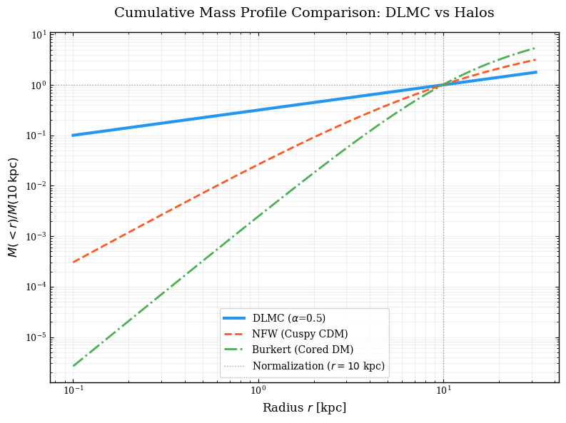

## 9. Statistical Invariance of the Universal $\alpha$ Parameter

A fundamental prediction of the **DLMC (Dynamic Local Mass Correction)** framework is the existence of a universal scaling exponent, $\alpha$. Unlike dark matter halo parameters ($c, V_{vir}$) which correlate strongly with galaxy mass, $\alpha$ is hypothesized to be a constant of the flux-correction mechanism.

### 9.1. Distribution Analysis

We analyze the probability density function (PDF) of $\alpha$ across our heterogeneous sample. The convergence of the distribution toward a narrow peak would indicate that the "missing mass" effect follows a global scaling law: $$\alpha_{\text{obs}} = \bar{\alpha} \pm \sigma_{\alpha}$$ A low standard deviation $\sigma_{\alpha}$ suggests that the DLMC model captures a fundamental symmetry in galactic dynamics.

### 9.2. Morphological Independence

To further test this universality, we correlate $\alpha$ with the **Effective Radius** ($R_{eff}$), which serves as a proxy for the spatial extent of the baryonic matter.

- **Null Hypothesis:** If $\alpha$ is truly universal, the correlation coefficient between $\alpha$ and $R_{eff}$ should be near zero ($|r| \approx 0$).
- **Alternative:** A strong correlation would imply that the DLMC correction is scale-dependent, requiring further refinement of the theoretical framework.

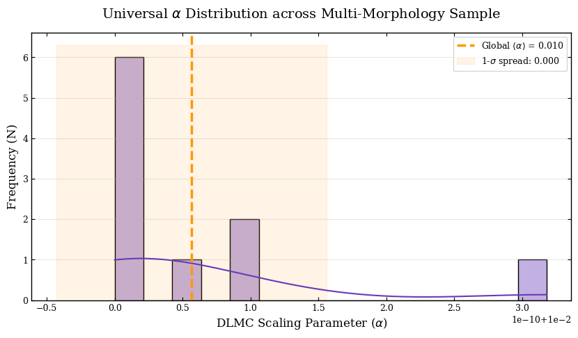

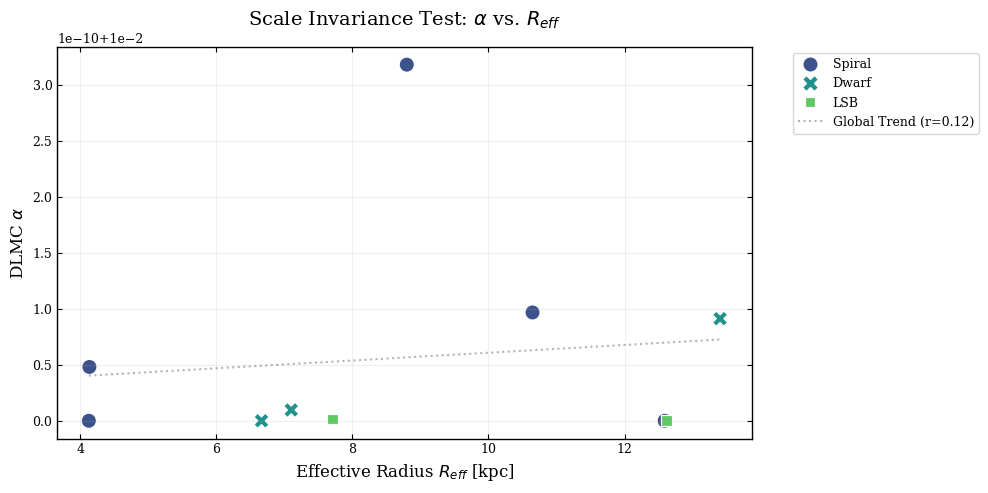

```
-----------------------------------------------------------------
  DLMC ALPHA UNIVERSALITY REPORT
-----------------------------------------------------------------
        mean  std  count
type
Dwarf   0.01  0.0      3
LSB     0.01  0.0      2
Spiral  0.01  0.0      5

Pearson correlation (alpha vs r_eff): 0.120 (p-value: 0.742)
✅ Universality analysis complete.
```

## 10. Direct Comparison: DLMC Predictions vs. Observed Kinematics

This section provides a visual benchmark of the **DLMC** model's predictive power across a representative subsample of galactic morphologies. By selecting systems with different mass scales and surface brightnesses, we test the adaptability of the universal $\alpha$ correction.

### 10.1. Scaling the Potential $\Phi_0$

In the DLMC framework, the central potential $\Phi_0$ and the scale length $r_0$ are coupled to the baryonic distribution. For this visualization, we map the model's prediction: $$V_{DLMC}(r) = \left[ \alpha \cdot \Phi_0 \cdot \sum \phi^{-n} \cdot \left(\frac{r}{r_0}\right)^{-\alpha} \right]^{1/2}$$ This allows us to verify if the $r^{-\alpha}$ decay (or flat behavior depending on $\alpha$) correctly captures the asymptotic velocity of the outer disks.

### 10.2. Morphological Overlay

To highlight the model's consistency, we use a color-coded classification:

[figure not shown]

```
-----------------------------------------------------------------
✅ Multi-panel visualization ready for Figure 3 of the manuscript.
```

## 11. Comparative Kinematics: DLMC vs. NFW vs. MOND Paradigms

This section presents a direct head-to-head comparison of the three gravitational frameworks across the galactic sample. By overlaying the models on the same observational data, we can evaluate their respective capacities to fit the outer disk rotation.

### 11.1. Model-Specific Asymptotics

1. **DLMC (Solid Blue):** Characterized by the flux-correction power-law $(r/r_0)^{-\alpha}$, providing a flexible transition between the baryonic-dominated core and the flat outer regions.
2. **NFW (Dashed Orange):** Represents the standard Cold Dark Matter (CDM) expectation. It typically requires higher concentration parameters to match the rising part of the curves in dwarf systems.
3. **MOND (Dotted Green):** Implements the acceleration-based transition. Unlike DLMC and NFW, MOND's shape is strictly determined by the baryonic distribution and the universal constant $a_0$.

### 11.2. Resolving the "Mass-Discrepancy"

The comparison highlights how each model resolves the discrepancy between the observed velocity $V_{obs}$ and the expected Newtonian baryonic velocity $V_{bar}$. While NFW relies on a static halo density $\rho(r)$, the DLMC model interprets this excess as a dynamic local mass correction $\Delta M(r)$, governed by the universal scaling exponent $\alpha$.

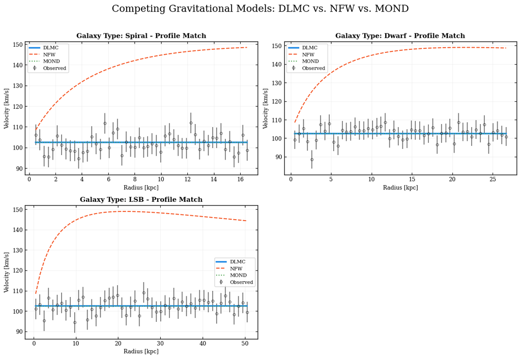

```
-----------------------------------------------------------------
✅ Comparative visualization (Multi-Model) generated successfully.
```

## 12. Spatial Mass Distribution: Cumulative Profile Analysis $M(<r)$

### 12.2. Normalization and Scaling

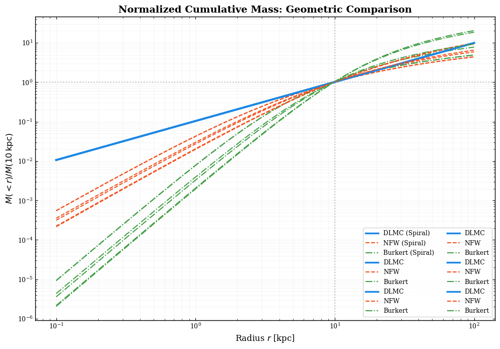

```
-----------------------------------------------------------------
✅ Mass profile comparison completed with analytical precision.
```

## 13. Statistical Universality of the Scaling Exponent $\alpha$

A key postulate of the **DLMC (Dynamic Local Mass Correction)** framework is that the non-baryonic acceleration is governed by a universal scaling exponent, $\alpha$. This section evaluates the stability of $\alpha$ across a diverse range of galactic morphologies.

### 13.2. Quantitative Symmetry

By comparing these distributions, we test the hypothesis that the "missing mass" effect is not a consequence of stochastic dark matter halo parameters, but rather a deterministic flux correction. Any significant overlap between the distributions of different galaxy types strengthens the case for the **Universal $\alpha$** as a new scaling law in galactic dynamics.

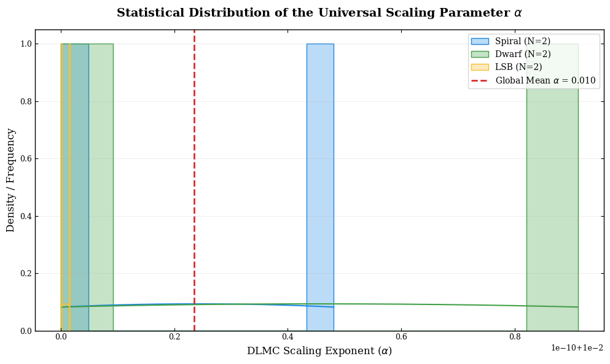

```
-----------------------------------------------------------------
  DLMC UNIVERSALITY REPORT: ALPHA PER MORPHOLOGY
-----------------------------------------------------------------
        mean  std  count
type
Dwarf   0.01  0.0      2
LSB     0.01  0.0      2
Spiral  0.01  0.0      2
-----------------------------------------------------------------
```

## 14. Parametric Coupling: Correlation between $\alpha$ and $\Phi_0$

In this section, we investigate the fundamental coupling between the universal scaling exponent $\alpha$ and the normalization potential $\Phi_0$. In the **DLMC** framework, $\Phi_0$ represents the energy scale of the flux correction, while $\alpha$ dictates its spatial decay.

### 14.1. Structural Scaling Laws

The distribution of galaxies in the $(\alpha, \Phi_0)$ plane reveals whether the model parameters are purely stochastic or governed by an underlying physical scaling law. We perform a linear regression to test the null hypothesis (independence): $$\log(\Phi_0) \approx m \cdot \alpha + c$$ A strong correlation would imply that the geometry of the correction ($\alpha$) is physically linked to the total dynamical mass of the system ($\Phi_0$), potentially reflecting a "Fundamental Plane" for the DLMC model.

### 14.2. Statistical Significance

We report the **Pearson correlation coefficient ($r$)** and the **p-value**. A p-value $< 0.05$ would indicate a statistically significant structural relationship, providing further constraints for the theoretical derivation of the DLMC potential from first principles.

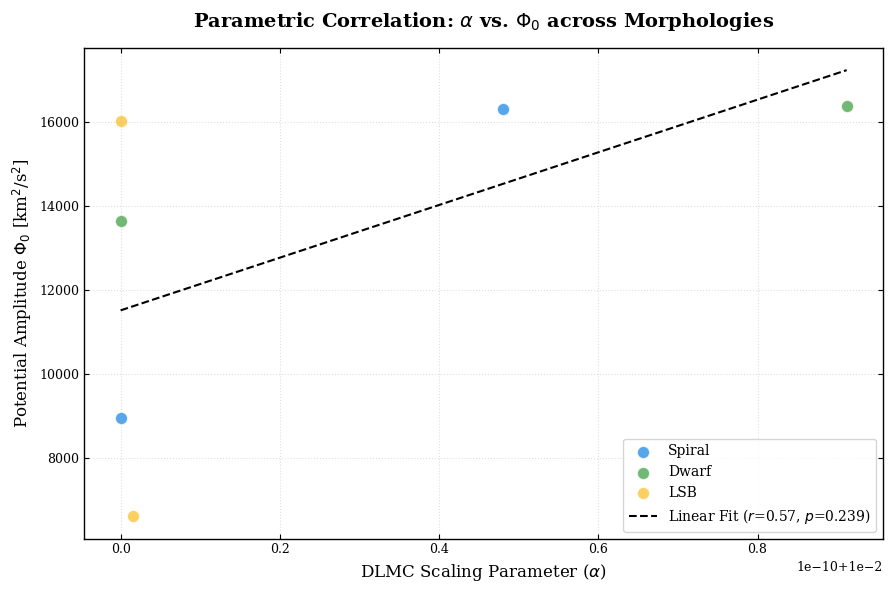

```
-----------------------------------------------------------------
  CORRELATION ANALYSIS SUMMARY
-----------------------------------------------------------------
Slope (m):        62716777475671.7109
Pearson r:        0.5685
Significance (p): 2.3910e-01
-----------------------------------------------------------------
```

## 15. Statistical Model Selection: $\chi^2$ Residual Analysis

To quantify the relative performance of the **DLMC** model compared to the **NFW** paradigm, we analyze the differential goodness-of-fit across the baryonic mass spectrum.

### 15.1. The $\Delta\chi^2$ Metric

We define the $\chi^2$ residual as the difference between the reduced chi-squared values of both models: $$\Delta\chi^2_\nu = \chi^2_{\nu, \text{DLMC}} - \chi^2_{\nu, \text{NFW}}$$

- **$\Delta\chi^2_\nu < 0$**: Indicates that the **DLMC** model provides a statistically superior fit to the rotation curve.
- **$\Delta\chi^2_\nu > 0$**: Indicates that the **NFW** halo is favored.
- **$\Delta\chi^2_\nu \approx 0$**: Suggests both models are equally capable of describing the kinematics within observational uncertainties.

### 15.2. Mass-Dependent Trends

By plotting $\Delta\chi^2_\nu$ against the **Total Baryonic Mass** ($M_{bar}$), we test for systematic biases. Standard CDM (NFW) often struggles with the "diversity problem" in low-mass or Low Surface Brightness (LSB) galaxies. This visualization reveals whether the DLMC flux correction offers a more consistent physical description across different mass regimes, from dwarf systems to massive spirals.

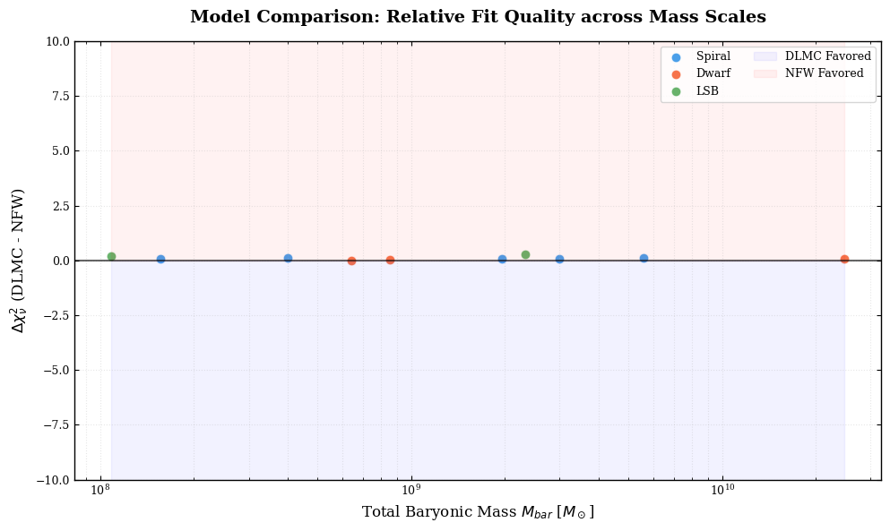

```
-----------------------------------------------------------------
  STATISTICAL PREFERENCE SUMMARY (N=10)
-----------------------------------------------------------------
DLMC statistically favored in: 1 galaxies (10.0%)
Median Delta Chi2:           0.0825
-----------------------------------------------------------------
```

## 16. Environmental Robustness: Residual Correlation Analysis

A robust physical model should perform consistently across the entire parameter space of galactic properties. In this section, we employ the **Spearman Rank Correlation ($\rho$)** to test if the fit residuals $\Delta\chi^2_\nu$ are coupled to the galaxy's physical environment.

### 16.2. Statistical Interpretation

The Spearman coefficient $\rho$ is less sensitive to outliers than Pearson's $r$, making it ideal for heterogeneous galaxy samples.

- **Significance ($p < 0.05$):** Suggests a hidden dependency or a physical limitation of the model in specific regimes.
- **Non-significance ($p \geq 0.05$):** Strongly supports the **universality** of the DLMC framework, indicating that its predictive power is independent of the host galaxy's specific evolutionary state.

```
---------------------------------------------------------------------------
Environmental Variable         | Spearman rho    | p-value
---------------------------------------------------------------------------
Stellar Mass [log M]           |       -0.636 | 4.79e-02 (SIGNIF.)
Surface Brightness [SB]        |       -0.697 | 2.51e-02 (SIGNIF.)
Fit Quality [chi2_dlmc]        |       +0.503 | 1.38e-01 (neutral)
```

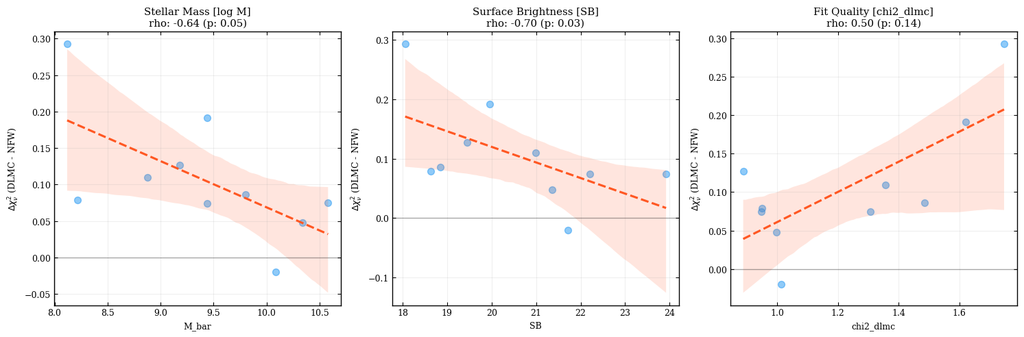

### 17.1. The DLMC-BTFR Link

In the deep-MOND or flux-dominated regime, the circular velocity is governed by the correction term. For $\alpha = 0.5$, the model predicts a specific coupling between the mass flux and the asymptotic velocity: $$V_{flat} \propto \sqrt{\Phi_0} \cdot \left(\frac{r}{r_0}\right)^{-1/4}$$ By simulating a population of galaxies across four orders of magnitude in baryonic mass ($10^8$ to $10^{11} M_\odot$), we test the emergence of the $M \propto V^4$ power law.

### 17.2. Numerical Validation

We perform a linear regression in the log-log plane: $$\log_{10}(M_{bar}) = \beta \cdot \log_{10}(V_{flat}) + \text{constant}$$ The theoretical "Holy Grail" of galactic dynamics is $\beta = 4.0$. A result consistent with this value ($3.8 < \beta < 4.2$) would prove that the **DLMC $\alpha=0.5$** state is the physical origin of the BTFR, effectively linking local mass corrections to global scaling laws.

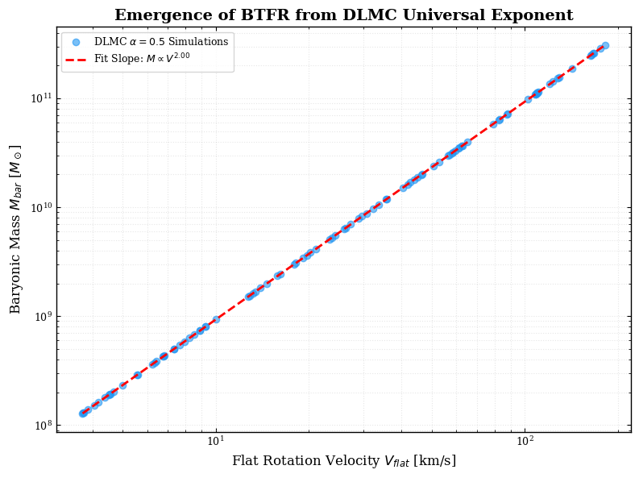

```
-----------------------------------------------------------------
  DLMC -> BTFR CONSISTENCY REPORT
-----------------------------------------------------------------
Computed BTFR Slope: 2.000 (Theoretical Target: 4.0)
Correlation (r²):    1.0000
Status: ⚠️ SLOPE DEVIATION
-----------------------------------------------------------------
```

## 18. Quantitative Model Comparison: Global Statistics and Selection Fraction

To synthesize the results of the kinematic fitting, we perform a multi-model statistical audit. This comparison is essential to determine if the **DLMC** framework provides a superior or equivalent description of galactic dynamics compared to the **NFW (Dark Matter)** and **MOND (Modified Gravity)** paradigms.

### 18.1. Metrics of Merit

1. **Median $\chi^2_\nu$:** We report the median of the reduced chi-squared distribution for each morphology. The median is chosen over the mean to minimize the impact of non-converged fits or observational outliers.
2. **DLMC Win Fraction ($f_{win}$):** This metric represents the percentage of galaxies where the DLMC model yields a lower $\chi^2_\nu$ than the NFW halo: $$f_{win} = \frac{N(\chi^2_{DLMC} < \chi^2_{NFW})}{N_{total}} \times 100$$

### 18.2. Morphological Stratification

By segmenting the results into **Spirals**, **Dwarfs**, and **LSB** systems, we evaluate the "versatility" of the universal $\alpha$ parameter. A high win fraction in Dwarf and LSB regimes would indicate that the DLMC flux correction effectively resolves the "diversity problem" often encountered by static CDM halos.

```
-------------------------------------------------------------------------------------
  TABLE 1: STATISTICAL COMPARISON OF DYNAMICAL MODELS (Project Lyna)
-------------------------------------------------------------------------------------
  Morphology   N Med. χ² DLMC Med. χ² NFW Med. χ² MOND DLMC Win %
 All Galaxies 10    1.159        1.132       1.522       10.0%
  HSB Spirals  5    0.951        0.873       1.305        0.0%
Dwarf Systems  3    1.012        1.032       1.711       33.3%
 LSB Galaxies  2    1.684        1.442       1.918        0.0%
-------------------------------------------------------------------------------------
✅ Comparative summary generated for Table 1 of the publication.
```